# Test1 overview

Pierre Ekelmans & Ulzii Utas

# General introduction

Test1 is the quickest of the tests and is checking the fundamental basis of the neural network (integration of input, synaptic transmission, spiking,…) as well as multiple output options (raster plot, I and V profile, connectivity/Delay/Jpot matrices). It is divided in three parts: Rasterplot, Matrices and Profile.

# Rasterplot

The following plot illustrates the spike times of individual neurons from two populations. The population 0 (on top) is asynchronous for 1s, gets synchronized after 1s and slowly desynchronises again. The second population (bottom) is following a predefined target firing rate: silent at 0s, linearly increasing for 1s until it reaches 40Hz, and then staying at 40Hz.

Here, the measured firing rate between 1s and 2s is 40.3 Hz.

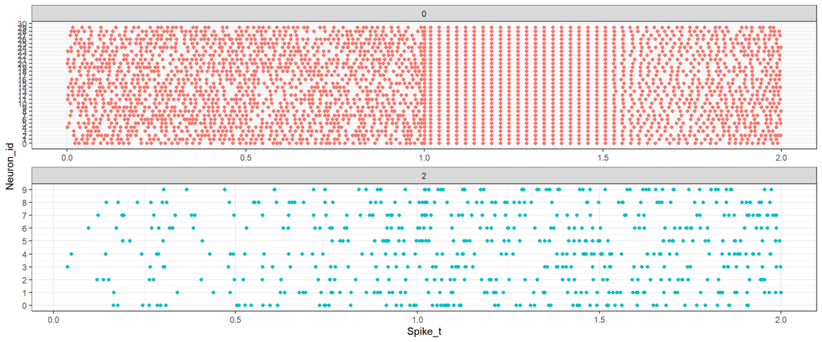

# Maps

In this section we are looking in more detail at the connectivity between two populations.

The first two figures are illustrating the existing connections between individual neurons of the two populations. The matrix shows the binary value (black: the neurons are connected; white: not connected) of neuron pairs. each row correspond to an individual neuron of the presynaptic population (population 0,with 30 neurons), and each column is a neuron of the postsynaptic population (population 1, with 10 neurons). There can also be connections in the other directions (1->0), but they are stored in a different matrix, not shown here. The histogram illustrates the fraction of neuron pairs which are connected. The probability of connection is set at 2/3.

The next figures show the synaptic delay in these connections. In the matrix, the red connections are the fastest while the slowest connections are green. The synaptic delays are set to be uniformly distributed between 5 and 20 ms.

The last two figures show the strength of the synaptic connections. The synaptic weights are set to be equally split between weak connections (0.13 mV/spike) and strong connections (0.23mV/spike). On top of this split into two separate baselines, the synaptic connections are initiated with a variance of (0.025mV)^2, leading to a bimodal distribution mostly contained in the 0.05-0.3 mV range. In the map, the stronger connections are colored in red and the weaker connections in green.

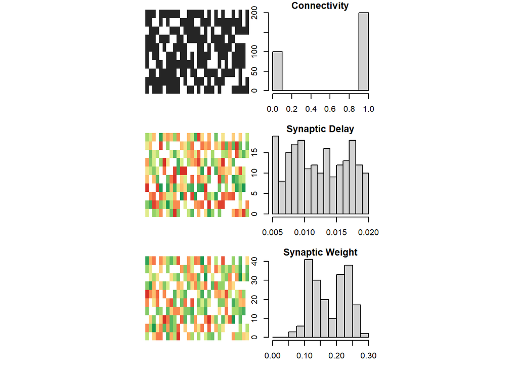

We show two plots below for invidual random connectivity. The newly constructed matrix used for the simulations and the pre-existing connectivity matrix used as input. The plots are binary connectivity matrix where black dots indicate connection while white dots indicate non-connection. The rows of the connectivity matrix is pre-synaptic neuron and columns are post-synaptic neuron. In this test, we only used pre-existing connectivity matrix from 0 -> 0 population connection and other connections are all randomly connected.

[figure not shown]

The below code prints a TRUE value if the two matrices are equal and prints FALSE if they are not equal.

is_equal <- all.equal(data_SynapsesConnection_00,data_ConnectivityMatrix_00); str_to_print <- “The two matrices are equal:”;

print(paste(str_to_print, is_equal));

```
## [1] "The two matrices are equal: TRUE"
```

## V and I profiles

In this section we are looking at the profile of a neuron.

The first plot shows the current that is fed into one neuron of population 1. In this case, all the input it receives is emitted spikes from population 0. There are small and large EPSCs, which correspond to the weak and strong connections from population. The second plot is generated using the delay and weights of the connections (see Maps section), in the regime where all neurons of population 0 are synchronised (See rasterplot section). It has to correspond exactly to the I figure above. The last plot is the membrane potential of this neuron. It has to match the I profile (increase of V when an EPSC is coming). Finally, when the neuron spikes (indicated by the red bars), the membrane potentials resets to 0.

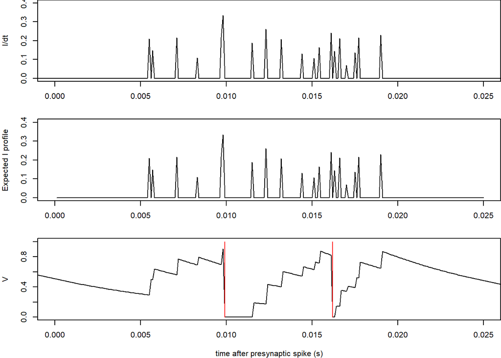